# Home Work 3 (Case Study 1) – Collecting, Manipulating and Blending Data from Twitter

Christopher Defreitas

DS501 - Introduction to Data Science

## Introduction

- This report describes analysis done on Twitter data using R
- The twitter package that was used is rtweet
- This package can be downloaded here: https://github.com/mkearney/rtweet

## Problem 1: Sampling Twitter Data with Streaming API about a certain topic

- The topic used to collect data for this analysis was Bitcoin. Bitcoin is a cryptocurrency that is traded on online exchanges. This is an interesting topic because the market for Bitcoin is highly volatile and subject to social events. The market is dominated by two main categories of emotions known as FUD (fear, uncertainty, and doubt) and FOMO (fear of missing out). The ability to mine twitter activity to extract the current sentiment of the market would be valuable for modeling the price of Bitcoin. This analysis lays some of the ground work for that larger goal.
- The tweets that are collected will be stored in a local text file.
- The data is collected using the twitter API. It will include 500 tweets and will not exclude retweets. The results will include tweets that would be returned by searching for bitcoin on the twitter homepage. Each row of the dataframe contains the tweet, characteristics about the tweet, and information about the users involved in the tweet.

```r
## request tweets
df = data.frame()
df = search_tweets('bitcoin', n=500, lang='en', include_rts=T)

## save data to unique file name
timestamp_str = format(Sys.time(), "%Y%m%d%H%M%S")
fname = paste0("TwitterData", timestamp_str, '.csv')
rtweet::write_as_csv(df, fname)
```

```r
nrow(df)
```

```
## [1] 488
```

```r
paste("Time range for tweets collected: ", min(df$created_at), "-", max(df$created_at))
```

```
## [1] "Time range for tweets collected:  2019-11-27 03:42:45 - 2019-11-27 03:59:43"
```

Report some statistics about the tweets you collected

## Problem 2: Analyzing Tweets and Tweet Entities with Frequency Analysis

**1. Word Count:**

- The most important step in text mining is data cleaning. Several steps were taken to clean the data before analyzing the word count. The purpose of this is to make sure that the analysis is not thrown off by bad data formatting.
- Data cleaning steps include removing line breaks, removing urls, removing punctuation, and removing non-ASCII characters. In this case the non-ASCII characters are mainly emojis.

```r
library(stringr)
# Remove line breaks from text. Replacing with spaces.
df$clean_text = str_replace_all(df$text, "[\r\n]" , " ")

# Remove links
library (devtools)
#install_github("trinker/qdapRegex")
library(qdapRegex)
df$clean_text = rm_url(df$clean_text, pattern=pastex("@rm_twitter_url", "@rm_url"))

# Remove punctuation
df$clean_text = str_replace_all(df$clean_text, "[\"():;\\-]" , " ")
df$clean_text = str_replace_all(df$clean_text, "[.,!?|+#$]" , "")

# Remove non-ascii characters (emojis)
df$clean_text = gsub("[^\x01-\x7F]", "", df$clean_text)
```

```r
show(df[,c('clean_text', 'text')])
```

```
## # A tibble: 488 x 2
##    clean_text                            text
##    <chr>                                 <chr>
##  1 Receive free 1000 P2PX tokens with E~ "Receive free 1,000 P2PX tokens w~
##  2 Receive free 5000 LCX tokens with Ex~ "Receive free 5,000 LCX tokens wi~
##  3 Receive free 50 YUSDT tokens with Ex~ "Receive free 50 YUSDT tokens wit~
##  4 @SDLerner The very institutions afte~ "@SDLerner The very institutions ~
##  5 @SDLerner Bitcoin Cash is not about ~ "@SDLerner Bitcoin Cash is not ab~
##  6 @extstock @networkp2p Nice airdrop c~ @extstock @networkp2p Nice airdro~
##  7 @extstock @storeum Nice project Than~ "@extstock @storeum Nice project.~
##  8 Receive free 50 YUSDT tokens with Ex~ "Receive free 50 YUSDT tokens wit~
##  9 Receive free 1000 P2PX tokens with E~ "Receive free 1,000 P2PX tokens w~
## 10 Receive free 2000 STO tokens with Ex~ "Receive free 2,000 STO tokens wi~
## # ... with 478 more rows
```

- The next step is to separate the cleaned tweets into individual words.
- The words are tokenized by splitting on white-space, and converting all characters to lower case.

```r
# Create a column of words
df$word = str_split(df$clean_text, ' +')

# Create dataframe with a row for each status, and a list of words
words_df = df[,c('status_id', 'word')]
library(tidyr)
words_df = unnest(words_df, word)

# Make all characters lowercase
words_df$word = tolower(words_df$word)
```

- Stop words are words that are very common in the target language and do not contribute much to the meaning of the sentence.
- Removing these words allows the analysis to focus on only words that are related to the subject of the message.

[output not shown]

```r
library(dplyr)
word_count = dplyr::arrange(word_count, desc(freq))
```

[output not shown]

- After counting the frequency of each word, there is a chance to do more data cleaning.
- Numbers, percentages, and encodings are removed. User mentions are also removed because there were not found to contribute specifically to the topics of the tweets. Regular expressions are used to remove these words because they follow a specific format that is easy to detect.

```r
# Remove Numbers, percentages, and encodings (&amp)
word_count = word_count[grep("^[0-9]*$|^[0-9]*%$|^[0-9]*k$|&[a-z]*", word_count$x, invert = TRUE) , ]

# Remove user metions
word_count = word_count[grep("^@[0-z]*$", word_count$x, invert = TRUE) , ]
```

- Display a table of the top 30 words with their counts

```r
top_30_words = word_count[1:30,]
show(top_30_words)
```

```
##                 x freq
## 1         bitcoin  549
## 2  cryptocurrency  203
## 3        extstock  115
## 4          follow  114
## 5             btc  110
## 6           tweet   95
## 9        ethereum   74
## 12             us   72
## 13        airdrop   69
## 14           free   69
## 15             rt   68
## 16            lcx   67
## 19        comment   61
## 20         tokens   61
```

[output cut: 16 more lines]

- The word cloud shows the most common words used in this collection of tweets. It is no surprise the bitcoin is the most common word because it was the search term.

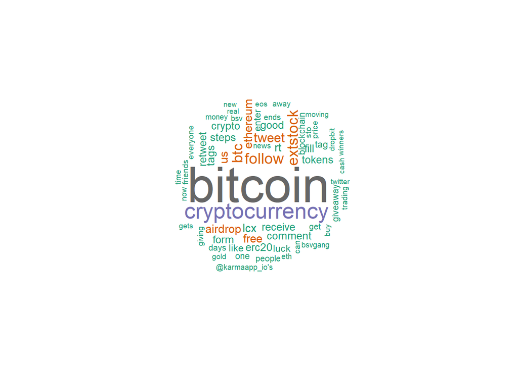

```r
#install.packages("wordcloud") # word-cloud generator
#install.packages("RColorBrewer") # color palettes
library("wordcloud")
library("RColorBrewer")
wordcloud(words = word_count$x, freq = word_count$freq, min.freq = 15,
          max.words=200, random.order=F, rot.per=0.35,
          colors=brewer.pal(8, "Dark2"))
```

**2. Find the most popular tweets in your collection of tweets**

- Two very common theme in the cryptocurrency community are giveaways. This is a way for a member of the community to generate a lot of attention by offering to give away money. When looking at the most retweeted tweets in the collection it is clear that giveaways that offer to give money to users who retweet their status are able to collect a large amount of retweets.

```r
# Most Retweets

df_retweets = df[df$is_retweet,]

df_retweets = df_retweets[!duplicated(df_retweets$retweet_status_id),]

show(dplyr::arrange(df_retweets, desc(retweet_count))[1:10,c('text', 'favorite_count', 'retweet_count')])
```

```
## # A tibble: 10 x 3
##    text                                        favorite_count retweet_count
##    <chr>                                                <int>         <int>
##  1 "Receive free 2,000 STO tokens with ExtSto~              0          2408
##  2 "Receive free 5,000 LCX tokens with ExtSto~              0          1585
##  3 Still concerned about a government “attack~              0          1487
##  4 "I’m giving away 3 $LTC &amp; .006 $BTC\n\~              0          1484
##  5 "\U0001f973 $200 #Bitcoin #CryptoGiveaway ~              0          1026
##  6 "Flight attendant: Is there a doctor on th~              0           944
##  7 "Receive free 50 YUSDT tokens with ExtStoc~              0           807
##  8 "Receive free 1,000 P2PX tokens with ExtSt~              0           770
##  9 "Bitcoin #giveaway \n\nWin $137 worth of B~              0           670
## 10 "\U0001f6a8$100 #Bitcoin #Crypto #Giveaway~              0           641
```

- The amount of favorited tweets in this data-set is very low because the tweets are streamed into the application. There is very little time for users to favorite a post. This also leads to slightly older posts having higher number of favorites. For this analysis the favorites on a very recent tweet should not be given much consideration.

```r
# Most Favorited Tweets

show(dplyr::arrange(df[!df$is_retweet,], desc(favorite_count))[1:10,c('text', 'favorite_count', 'retweet_count')])
```

```
## # A tibble: 10 x 3
##    text                                        favorite_count retweet_count
##    <chr>                                                <int>         <int>
##  1 "Veribit will be the first platform to pus~              3             2
##  2 "All I’m going to say is.. buy bitcoin. \n~              3             0
##  3 "@AgoristView @andzsy @brduprey @rogerkver~              2             0
##  4 @stacyherbert These people are insane. Tha~              2             0
##  5 "\U0001f680\U0001f680book ur hotel with 50~              2             0
##  6 "Some coins are fighting for BTC title. Th~              2             0
##  7 "$BTC - Our Some past analysis\n\n- The se~              1             0
##  8 "@Crystamped nulltxnews you just received ~              1             0
##  9 Honestly to be honest investing in bitcoin~              1             0
## 10 "@Asameow17 \n\U0001f338TIPPIN TIME\U0001f~              1             0
```

**3. Find the most popular Tweet Entities in your collection of tweets**

Please display a table of the top 10 hashtags, top 10 user mentions that are the most popular in your collection of tweets.

```r
## define as a function
getTopListColumn <- function(d, colname, n, wc_min_freq){

  d = d[,c('status_id', colname)]
  names(d) = c('status_id', 'x')

  # Flatten lists of elements into individual rows
  d = tidyr::unnest(d)

  # Convert  to lower case
  d$x = tolower(d$x)

  # Remove blanks
  d = d[!is.na(d$x),]

  # Count hashtags
  d_count = plyr::count(d$x)

  # Show the top n most popular elements
  top = dplyr::arrange(d_count, desc(freq))[1:n,]
  show(top)

  wordcloud(words = d_count$x, freq = d_count$freq, min.freq = wc_min_freq,
          max.words=200, random.order=F, rot.per=0.35,
          colors=brewer.pal(8, "Dark2"))
}
```

```r
getTopListColumn(df, 'hashtags', 10, 8)
```

```
##                 x freq
## 1         bitcoin  145
## 2  cryptocurrency   47
## 3             btc   31
## 4          crypto   30
## 5         bsvgang   18
## 6        giveaway   14
## 7      blockchain   11
## 8             eth   11
## 9       bitcoinsv    9
## 10       litecoin    8
```

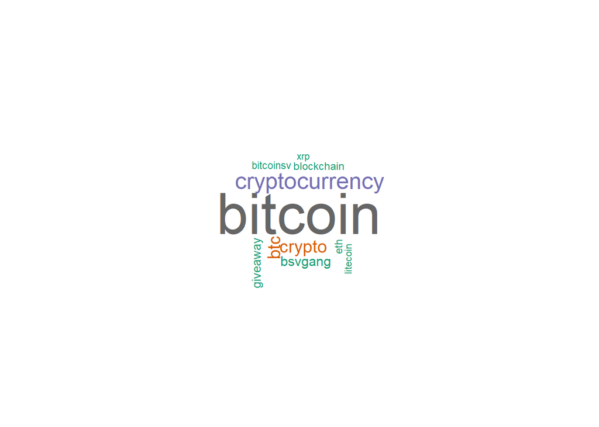

- In the cryptocurrency-twitter world, the ticker symbols for a currency are often tagged in tweets in a similar way to hashtags. They are preceded by a ‘$’ and serve as a consistent hashtag for cryptocurrency markets.

```r
getTopListColumn(df, 'symbols', 10, 1)
```

```
##         x freq
## 1     btc   44
## 2     nxs    3
## 3    abbc    2
## 4  btcusd    2
## 5     ltc    2
## 6    tpay    2
## 7    arwr    1
## 8     eth    1
## 9    gold    1
## 10    usd    1
```

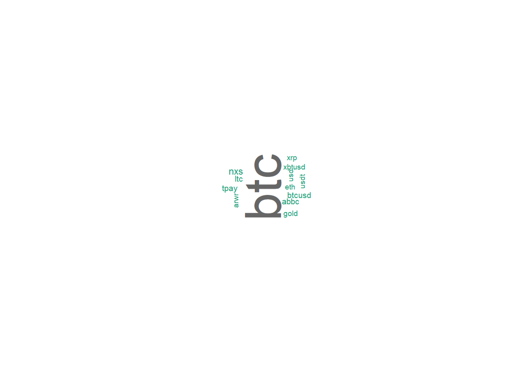

```r
getTopListColumn(df, 'mentions_screen_name', 10, 10)
```

```
##                  x freq
## 1         extstock  150
## 2             heat   36
## 3  irishgirlcrypt1   25
## 4              lcx   19
## 5      karmaapp_io   11
## 6           wax_io   11
## 7          bsvgang    9
## 8       diegoioisp    9
## 9    bitcoin_clara    8
## 10  linkupfounders    8
```

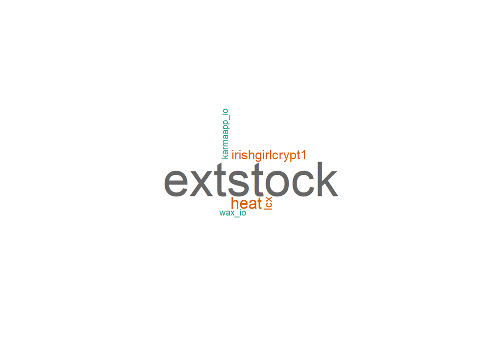

## Problem 3: Getting any 20 friends and any 20 followers of a popular user in twitter

- The popular user account used for this analysis is the Trevon James https://twitter.com/BitcoinTre
- James is a popular youtube personality in the cryptocurrency community. He was an avid promoted of the popular ponzi scheme named bitconnect [https://fortune.com/2018/01/17/bitcoin-bitconnect-price-scam/].
- Get the list of all friends and all followers of the twitter user.
- Display 20 out of the followers, Display their ID numbers and screen names in a table.
- Display 20 out of the friends (if the user has more than 20 friends), Display their ID numbers and screen names in a table.
- Compute the mutual friends within the two groups, i.e., the users who are in both friend list and follower list, Display their ID numbers and screen names in a table

```r
user = rtweet::lookup_users('BitcoinTre')
user_id = user[1,'user_id'][[1]]
```

```r
# Collect followers and friends
print(paste0("Number of friends of ", user$screen_name, ': ', user$friends_count))
```

```
## [1] "Number of friends of BitcoinTre: 64"
```

```r
friends = rtweet::get_friends(user_id, n=user$friends_count, retryonratelimit = TRUE)['user_id']
nrow(friends)
```

```
## [1] 64
```

```r
print(paste0("Number of followers of ", user$screen_name, ': ', user$followers_count))
```

```
## [1] "Number of followers of BitcoinTre: 24492"
```

```r
followers = rtweet::get_followers(user_id, n=user$followers_count, retryonratelimit = T) # Change retryonratelimit to TRUE to collect the full list of followers.
```

```
## 75000 followers!
```

```r
nrow(followers)
```

```
## [1] 24492
```

```r
# Preview the account data for the followers and friends
show(rtweet::lookup_users(followers$user_id)[,c('screen_name','user_id')])
```

```
## # A tibble: 24,492 x 2
##    screen_name    user_id
##    <chr>          <chr>
##  1 KendaHeralda   286640056
##  2 taylor_boggis  985864544302985217
##  3 Iren58865275   1156542348274348032
##  4 Kvngoc1        1062330146013831169
##  5 MackMcDonaldJr 783836302038867968
##  6 Ninoskaavila   166419133
##  7 ToraykB        1197691731879305216
##  8 olawoki007     1153616148367327232
##  9 xShady777      1021768653950341120
## 10 Eliah48120861  1190223450641702913
## # ... with 24,482 more rows
```

```r
show(rtweet::lookup_users(friends$user_id)[,c('screen_name','user_id')])
```

```
## # A tibble: 64 x 2
##    screen_name     user_id
##    <chr>           <chr>
##  1 betfury_io      1164253322423021570
##  2 digitalikNet    376218668
##  3 Rhythmtrader    944261020914249729
##  4 parabolictrav   2449847450
##  5 100trillionUSD  918804624303382528
##  6 tewkenaire      1166366307345977345
##  7 Fat_macedonian  1105871573871984640
##  8 MustacheTommy   75149736
##  9 ICONbetofficial 1142121597643317248
## 10 Treyarch        46423291
## # ... with 54 more rows
```

```r
# Find followers who are also friends
f_and_f = dplyr::inner_join(followers, friends, by='user_id', suffix=c('.followers', '.friends'))
nrow(f_and_f)
```

```
## [1] 16
```

```r
# Collect account data
f_and_f = rtweet::lookup_users(f_and_f$user_id)

# Show the users who are friends with and follow the user. Showing most followed users first.
f_and_f = dplyr::arrange(f_and_f, desc(f_and_f$followers_count))
show(f_and_f[1:20,c('screen_name', 'location', 'verified', 'followers_count', 'friends_count')])
```

```
## # A tibble: 20 x 5
##    screen_name     location          verified followers_count friends_count
##    <chr>           <chr>             <lgl>              <int>         <int>
##  1 TronWalletMe    World             FALSE              19518          3255
##  2 IG_Galaxy       Manchester, Engl~ FALSE               7953           800
##  3 Topia_Network   ""                FALSE               4105            67
##  4 FragToken       Tron Network      FALSE               3125           167
##  5 betfury_io      ""                FALSE               2929            24
##  6 TronVegasOnline TronVerse         FALSE               2404          1376
##  7 Bankroll_Status ""                FALSE               2134            58
##  8 PoWH3D          ""                FALSE               2122            77
##  9 tripjammer      ""                FALSE               1847           287
## 10 tewkenaire      ""                FALSE               1617            21
## 11 bitconnect      United States     FALSE                653            12
## 12 IOSTPlay        ""                FALSE                643            26
## 13 Fat_macedonian  Danmark           FALSE                337            80
## 14 BlazeMachine    TRON Blockchain   FALSE                249            83
## 15 DazMurray       ""                FALSE                224           360
## 16 DarwiniaNetwork ""                FALSE                198           110
## 17 <NA>            <NA>              NA                    NA            NA
## 18 <NA>            <NA>              NA                    NA            NA
## 19 <NA>            <NA>              NA                    NA            NA
## 20 <NA>            <NA>              NA                    NA            NA
```